# Lab14 - Speed Dating Data and Joins

tony sulfaro

4/10/2019

# Definitions

## 01

Relational Data

Relational data is data that relates to one another from different sources. There can be two datasets that have seperate entries but they can be combined through joins to get more information.

## 02

Primary Key

A primary key is a specific entry in a dataset that can be used to resolve other entries in the dataset. Eg: given a timestamp it is possible to get a specific entry from the dataset by looking up the row with the timestamp and then looking across at other entries.

## 03

Mutating Join

Add new variables to a data frame by matching observations in with one another. For example, if someone were working with some flights data and they had in one table departures and arrivals from airports and one column had a tail number they could resolve tail number to a planes table and get more information about the plane (plane type, passenger capacity, etc.).

## 04

Filtering Join

This type of command filters entries in a dataframe based on weather or not they match an observation in a table. This is different because rather than resolve data and add it to a dataframe they are filtering records based on existence in another table. For example if there were incoming flights one could filter the rows to planes that are from a specific carrier.

# Describe the Data

## 05

Each observation in the dates file is a date that two people went on, iid is a person and pid is the partner id that they went on the date with.

## 06

There are relations between iid and pid to an entry from the people table. Each iid and pid can be used to lookup a person from the people table.

## 07

Primary key of people table = iid (id of person on date that matches to pid in dates table)

## 08

```r
dates %>%
  count(iid) %>%
  filter(n >1)
```

```
## # A tibble: 386 x 2
##      iid     n
##    <dbl> <int>
##  1    21    16
##  2    22    16
##  3    23    16
##  4    24    16
##  5    25    16
##  6    26    16
##  7    27    16
##  8    28    16
##  9    29    16
## 10    30    16
## # … with 376 more rows
```

## 09

Add surrogate key

```r
dates = dates %>%
  mutate(surrogate.key = row_number())
dates
```

```
## # A tibble: 6,944 x 18
##      iid round position order   pid match dec    attr  sinc intel   fun
##    <dbl> <dbl>    <dbl> <dbl> <dbl> <chr> <chr> <dbl> <dbl> <dbl> <dbl>
##  1    21    16        5     6    40 No    No        6     8     7     9
##  2    21    16        5     7    41 No    No        5     8     7     5
##  3    21    16        5     8    42 No    Yes       8     9     8     8
##  4    21    16        5    11    43 No    No        5     8     8     4
##  5    21    16        5    15    44 No    No        7     7     8     5
##  6    21    16        5     2    45 No    No        6     8     8     6
##  7    21    16        5     5    46 No    No        6     8     8     6
##  8    21    16        5    12    47 No    No        4     7     7     4
##  9    21    16        5    16    48 No    No        7     7     7     5
## 10    21    16        5     3    49 No    Yes       9     9    10     9
## # … with 6,934 more rows, and 7 more variables: amb <dbl>, shar <dbl>,
## #   like <dbl>, prob <dbl>, met <chr>, match_es <dbl>, surrogate.key <int>
```

# Left Joins

## 10

```r
dates.people = dates %>%
 left_join(people, dates, by = c("iid" = "iid")) ## join by iid = iid (resolve person not participant to their attributes)
dates.people
```

```
## # A tibble: 6,944 x 28
##      iid round position order   pid match dec    attr  sinc intel   fun
##    <dbl> <dbl>    <dbl> <dbl> <dbl> <chr> <chr> <dbl> <dbl> <dbl> <dbl>
##  1    21    16        5     6    40 No    No        6     8     7     9
##  2    21    16        5     7    41 No    No        5     8     7     5
##  3    21    16        5     8    42 No    Yes       8     9     8     8
##  4    21    16        5    11    43 No    No        5     8     8     4
##  5    21    16        5    15    44 No    No        7     7     8     5
##  6    21    16        5     2    45 No    No        6     8     8     6
##  7    21    16        5     5    46 No    No        6     8     8     6
##  8    21    16        5    12    47 No    No        4     7     7     4
##  9    21    16        5    16    48 No    No        7     7     7     5
## 10    21    16        5     3    49 No    Yes       9     9    10     9
## # … with 6,934 more rows, and 17 more variables: amb <dbl>, shar <dbl>,
## #   like <dbl>, prob <dbl>, met <chr>, match_es <dbl>,
## #   surrogate.key <int>, gender <chr>, age <dbl>, race <dbl>,
## #   imprace <dbl>, imprelig <dbl>, goal <dbl>, date <dbl>, go_out <dbl>,
## #   exphappy <dbl>, expnum <dbl>
```

## 11

```r
dates.people = dates.people %>%
  select(iid, round, position, order, pid, match, dec, attr, sinc,intel,fun,amb,shar,like,prob,met,match_es,race)
dates.people
```

```
## # A tibble: 6,944 x 18
##      iid round position order   pid match dec    attr  sinc intel   fun
##    <dbl> <dbl>    <dbl> <dbl> <dbl> <chr> <chr> <dbl> <dbl> <dbl> <dbl>
##  1    21    16        5     6    40 No    No        6     8     7     9
##  2    21    16        5     7    41 No    No        5     8     7     5
##  3    21    16        5     8    42 No    Yes       8     9     8     8
##  4    21    16        5    11    43 No    No        5     8     8     4
##  5    21    16        5    15    44 No    No        7     7     8     5
##  6    21    16        5     2    45 No    No        6     8     8     6
##  7    21    16        5     5    46 No    No        6     8     8     6
##  8    21    16        5    12    47 No    No        4     7     7     4
##  9    21    16        5    16    48 No    No        7     7     7     5
## 10    21    16        5     3    49 No    Yes       9     9    10     9
## # … with 6,934 more rows, and 7 more variables: amb <dbl>, shar <dbl>,
## #   like <dbl>, prob <dbl>, met <chr>, match_es <dbl>, race <dbl>
```

## 12

```r
dates.people = dates.people %>%
 left_join(dates.people, dates, by = c("pid" = "iid")) ## resolve pid to date attributes, {attribute}.y is pid attributes
colnames(dates.people)
```

```
##  [1] "iid"        "round.x"    "position.x" "order.x"    "pid"
##  [6] "match.x"    "dec.x"      "attr.x"     "sinc.x"     "intel.x"
## [11] "fun.x"      "amb.x"      "shar.x"     "like.x"     "prob.x"
## [16] "met.x"      "match_es.x" "race.x"     "round.y"    "position.y"
## [21] "order.y"    "pid.y"      "match.y"    "dec.y"      "attr.y"
## [26] "sinc.y"     "intel.y"    "fun.y"      "amb.y"      "shar.y"
## [31] "like.y"     "prob.y"     "met.y"      "match_es.y" "race.y"
```

## 13

```r
dates.people = dates.people %>%
  select(iid,   pid,    round.x,    position.x, match.x,    like.x, race.x, race.y)
dates.people
```

```
## # A tibble: 128,246 x 8
##      iid   pid round.x position.x match.x like.x race.x race.y
##    <dbl> <dbl>   <dbl>      <dbl> <chr>    <dbl>  <dbl>  <dbl>
##  1    21    40      16          5 No           9      4      4
##  2    21    40      16          5 No           9      4      4
##  3    21    40      16          5 No           9      4      4
##  4    21    40      16          5 No           9      4      4
##  5    21    40      16          5 No           9      4      4
##  6    21    40      16          5 No           9      4      4
##  7    21    40      16          5 No           9      4      4
##  8    21    40      16          5 No           9      4      4
##  9    21    40      16          5 No           9      4      4
## 10    21    40      16          5 No           9      4      4
## # … with 128,236 more rows
```

# Answer a Question using Relational Data

## 14

```r
dates.people = dates.people %>%
  mutate(same.race = (race.x==race.y)) %>%
  filter(is.na(same.race) == FALSE)
dates.people
```

```
## # A tibble: 127,562 x 9
##      iid   pid round.x position.x match.x like.x race.x race.y same.race
##    <dbl> <dbl>   <dbl>      <dbl> <chr>    <dbl>  <dbl>  <dbl> <lgl>
##  1    21    40      16          5 No           9      4      4 TRUE
##  2    21    40      16          5 No           9      4      4 TRUE
##  3    21    40      16          5 No           9      4      4 TRUE
##  4    21    40      16          5 No           9      4      4 TRUE
##  5    21    40      16          5 No           9      4      4 TRUE
##  6    21    40      16          5 No           9      4      4 TRUE
##  7    21    40      16          5 No           9      4      4 TRUE
##  8    21    40      16          5 No           9      4      4 TRUE
##  9    21    40      16          5 No           9      4      4 TRUE
## 10    21    40      16          5 No           9      4      4 TRUE
## # … with 127,552 more rows
```

## 15

```r
a = dates.people %>%
  mutate(same.race = (race.x==race.y)) %>%
  filter(is.na(same.race) == FALSE) %>%
  group_by(match.x, same.race) %>%
  summarise(count = n())

a
```

```
## # A tibble: 4 x 3
## # Groups:   match.x [?]
##   match.x same.race count
##   <chr>   <lgl>     <int>
## 1 No      FALSE     63864
## 2 No      TRUE      43790
## 3 Yes     FALSE     11286
## 4 Yes     TRUE       8622
```

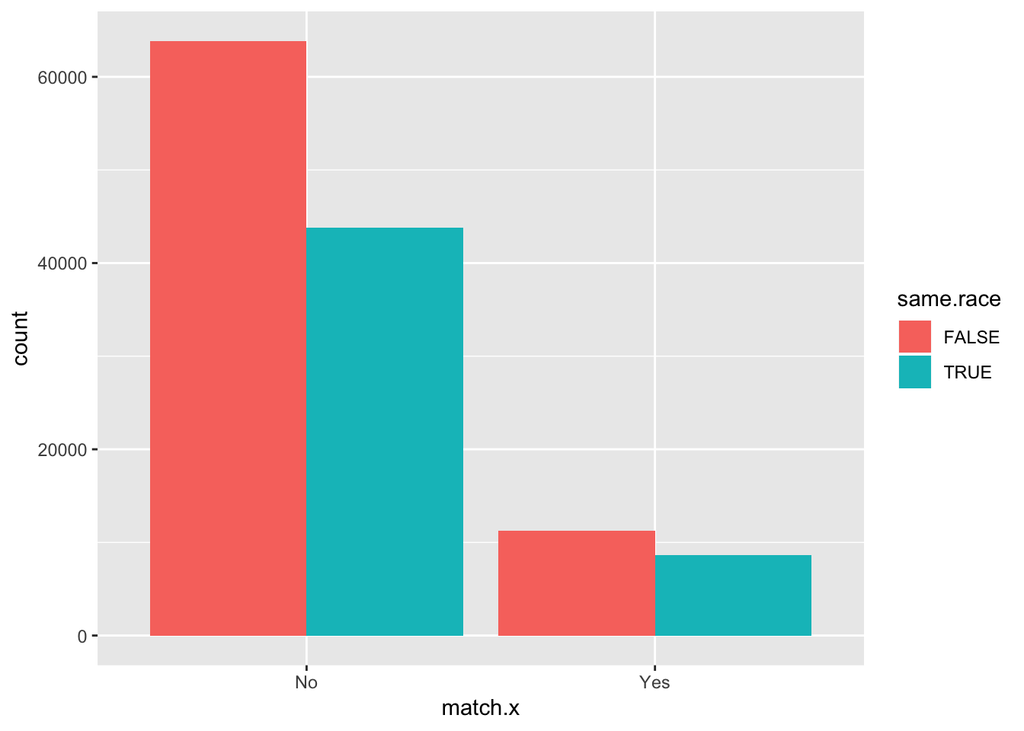

```r
ggplot(a, aes(x=match.x, y=count, fill=same.race)) +
  geom_bar(stat = "identity",position="dodge")
```

## 16

At first glance it may seem that race would affect weather or not people matched based how tall FALSE is on the “No” group compared to that of the “Yes” group.

However, Once you normalize the data by taking the relative percentage of yes to no values for each of the groups of bars we can see that they have similar proportions. The relative percentage of those who matched who had the same race were ~43.3% whereas the percentage of those who did not match with the same race were ~40.6%. This means that the proportion of those who said yes and no and who were in similar race groups are approximately the same.

As a result, race does not have an influence on weather or not people match when dating.

# Extra Credit

```r
people <- tribble(
 ~id, ~last.name, ~first.name,
 1, "Smith", "Alexander",
 2, "Williams", "Olivia",
 3, "Bell", "Emma",
 4, "Thompson", "Liam",
 5, "Garcia", "Sophia"
)
courses <- tribble(
 ~id, ~course.num, ~title, ~schedule, ~instructor, ~location,
~credits, ~prereqs,
 1, "MI220", "Understanding Users", "M W 3:00 PM - 4:20 PM", "Wash",
"233 Communication Arts Bldg", 3, NA,
 2, "MI250", "Intro Applied Programming", "M W 10:20 AM - 12:10 PM",
"Introne", "C134 Holden Hall", 3, NA,
 3, "MI320", "Reasoning with Data", "W 12:40 PM - 3:30 PM", "Rader",
"106 Farrall Ag Eng Hall", 3, "MI 220 and MI 250",
 4, "MI350", "Evaluating HCT", "Tu Th 10:20 AM - 12:10 PM", "Rader",
"233 Communication Arts Bldg", 3, "MI 220 and MI 250",
 5, "MI420", "Interactive Prototyping", "Tu Th 10:20 AM - 12:10 PM",
"Wyche", "C134 Holden Hall", 3, "MI 220 and MI 250"
)
people.courses <- tribble(
 ~person.id, ~course.id,
 1, 1,
 1, 2,
 2, 3,
 2, 4,
 3, 4,
 3, 5,
 4, 1,
 4, 2,
 5, 3,
 5, 4
)
```

After you have run the code to create the tables, a dplyr command that uses joins to create another data table that has more than one row per student, and the columns: last.name, first.name, course.num, title, schedule, instructor, location, credits, prereqs. This new data table lists which courses each student is registered for.

```r
people
```

```
## # A tibble: 5 x 3
##      id last.name first.name
##   <dbl> <chr>     <chr>
## 1     1 Smith     Alexander
## 2     2 Williams  Olivia
## 3     3 Bell      Emma
## 4     4 Thompson  Liam
## 5     5 Garcia    Sophia
```

```r
courses
```

```
## # A tibble: 5 x 8
##      id course.num title   schedule   instructor location   credits prereqs
##   <dbl> <chr>      <chr>   <chr>      <chr>      <chr>        <dbl> <chr>
## 1     1 MI220      Unders… M W 3:00 … Wash       233 Commu…       3 <NA>
## 2     2 MI250      Intro … M W 10:20… Introne    C134 Hold…       3 <NA>
## 3     3 MI320      Reason… W 12:40 P… Rader      106 Farra…       3 MI 220…
## 4     4 MI350      Evalua… Tu Th 10:… Rader      233 Commu…       3 MI 220…
## 5     5 MI420      Intera… Tu Th 10:… Wyche      C134 Hold…       3 MI 220…
```

```r
people.courses
```

```
## # A tibble: 10 x 2
##    person.id course.id
##        <dbl>     <dbl>
##  1         1         1
##  2         1         2
##  3         2         3
##  4         2         4
##  5         3         4
##  6         3         5
##  7         4         1
##  8         4         2
##  9         5         3
## 10         5         4
```

```r
new.table = left_join(people.courses, people, by = c("person.id" = "id"))
new.table = left_join(new.table, courses, by = c("course.id" = "id")) %>%
  select(last.name, first.name, course.num, title,  schedule,   instructor, location,   credits,    prereqs)
new.table
```

```
## # A tibble: 10 x 9
##    last.name first.name course.num title schedule instructor location
##    <chr>     <chr>      <chr>      <chr> <chr>    <chr>      <chr>
##  1 Smith     Alexander  MI220      Unde… M W 3:0… Wash       233 Com…
##  2 Smith     Alexander  MI250      Intr… M W 10:… Introne    C134 Ho…
##  3 Williams  Olivia     MI320      Reas… W 12:40… Rader      106 Far…
##  4 Williams  Olivia     MI350      Eval… Tu Th 1… Rader      233 Com…
##  5 Bell      Emma       MI350      Eval… Tu Th 1… Rader      233 Com…
##  6 Bell      Emma       MI420      Inte… Tu Th 1… Wyche      C134 Ho…
##  7 Thompson  Liam       MI220      Unde… M W 3:0… Wash       233 Com…
##  8 Thompson  Liam       MI250      Intr… M W 10:… Introne    C134 Ho…
##  9 Garcia    Sophia     MI320      Reas… W 12:40… Rader      106 Far…
## 10 Garcia    Sophia     MI350      Eval… Tu Th 1… Rader      233 Com…
## # … with 2 more variables: credits <dbl>, prereqs <chr>
```